# Raising awareness of harassment against politicians

Experimental evidence on the democratic consequences from four European democracies  
ECPR General Conference 2025

Søren Damsbo-Svendsen

**Karina Kosiara-Pedersen**

August 22, 2025

## Motivation

- Growing knowledge about **costs and risks of harassment** to politicians and candidates
  - also about implications in terms of stress, behavior, protection, exits
  - ultimately about democratic **representation**
  - **experimental (causal) evidence** is sparse, especially on *citizens*
- *RQ: How do **citizens** respond to **increased awareness** about harassment of politicians?*
- Preregistered **survey experiment**
  - large sample with **four European countries**
  - *treatments:* **true harassment stories**
  - *outcomes:* political (dis)**engagement and attitudes** on harassment and democracy
- Increasing awareness of harassment could have **bad implications**
  - if **citizens are deterred** from considering entering/engaging in politics
  - or if harassment awareness causes **cynicism, backlash, or apathy**

## Design

- New multinational preregistered **survey experiment**
- **n = 8,899**
  - Denmark: n = 5,008 (YouGov)
  - Germany: n = 1,519 (Prolific)
  - United Kingdom: n = 1,515
  - France: n = 857
- **Treatment**
  - **real stories** about (Danish) politicians’ experiences with harassment
  - stimulus sampling design
  - read and evaluate **5 harassment stories**
    - random draw from 55 curated, paraphrased stories
  - story **evaluation**: *seriousness*, *justifiableness*, *harmfulness*

## Outcomes

1. Perceived **prevalence** and personal **risk**
2. Three attitudes towards **harassment** in politics
3. Satisfaction with **democracy**
4. Willingness to **run for office** in the future
5. **Index** of willingness to **engage** in six political activities

[figure not shown]

## Treatment: 5/55 harassment stories<sup>1</sup>

> “I have experienced my election posters being ‘decapitated’ by unknown persons. My children, aged seven and nine, have seen this, which was very unpleasant.”

> “I have experienced unpleasant advances in private messages on social media from people of all ages.”

> “I have received death threats from unknown senders directed at both my little brothers and my own children.”

> “There was a citizen who drove around in a car and measured how high my - and only my - posters were placed from the ground. He then reported me to the police for banners that were placed too low.”
[^1]: *Source: Danish 2021 municipal election candidate survey (n = 3,986, response rate 42%)*

## Treatment: example

1. 1 of 4 **politician** *gender-age* groups (randomized)
2. **Story**
3. Three **evaluation** questions

*Repeats 5 times…*

[figure not shown]

Treatment example (1 out of 5) in Danish

## Story evaluations

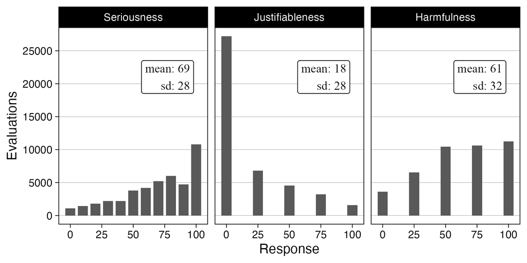

Evaluations of 43,460 harassment stories

# Results

## Effects of raising awareness on harassment attitudes

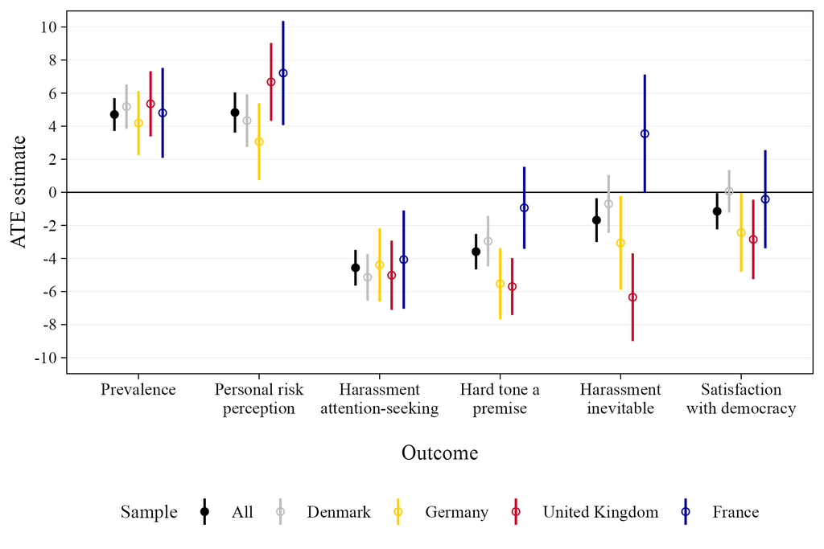

- 4.7 %-points *increase* in perceived **prevalence**
- 4.8 %-points *increase* in personal **risk perception**

## Effects of raising awareness on harassment attitudes

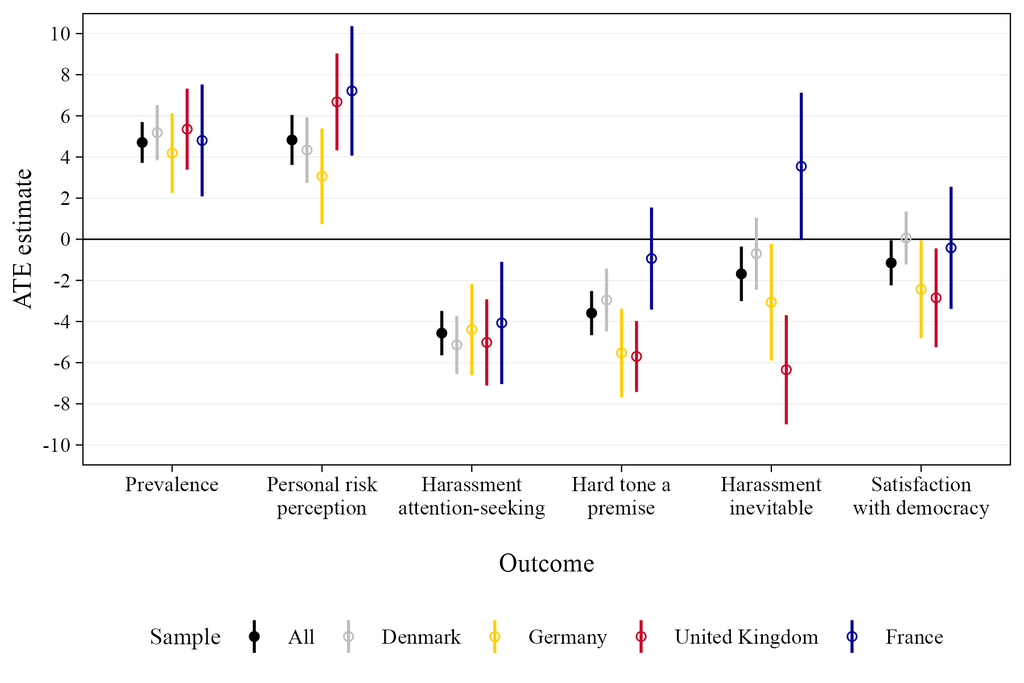

- 4.6 %-point *decrease* in belief that politicians’ harassment stories are **about getting attention**
- 3.6 %-point *decrease* in belief that politicians **should have known about hard tone**
- 1.7 %-point *decrease* in belief that **harassment is inevitable** (p = 0.013)
- 1.1 %-point *decrease* in general **satisfaction with democracy** (p = 0.040)

## Effects of raising awareness on political engagement

> *Main hypothesis: People become **politically disengaged** and **less likely to run for office** when they hear stories about harassment against politicians*

## Effects of raising awareness on political engagement

> *Main hypothesis: People become **politically disengaged** and **less likely to run for office** when they hear stories about harassment against politicians*

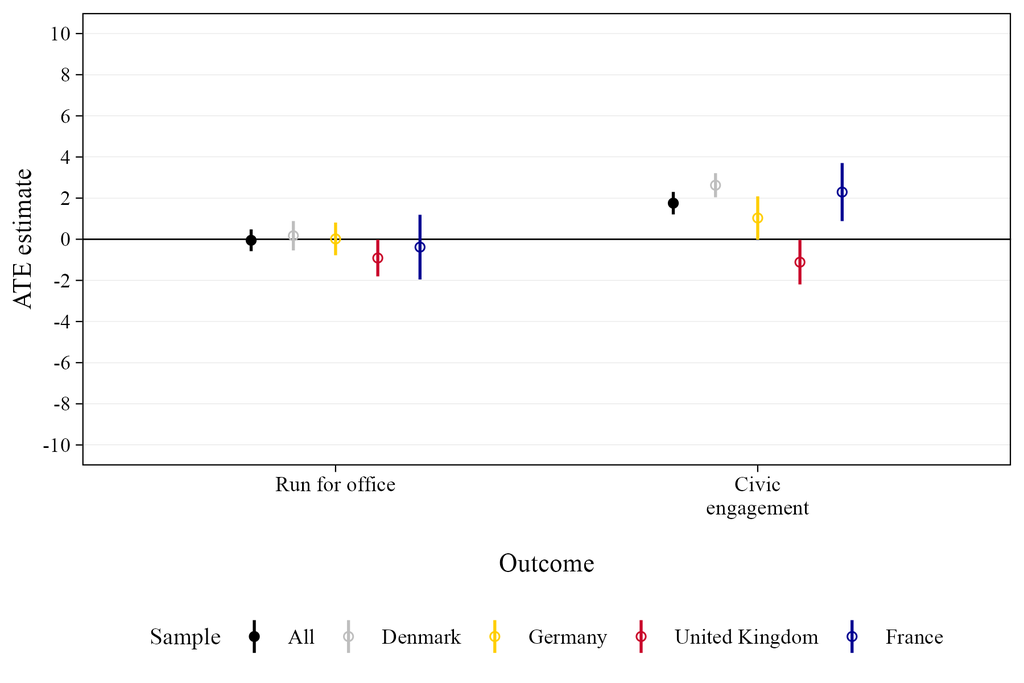

- No average decline in willingness to **run for office** (p = 0.851)
- No decline in **civic engagement**
- Instead, 1.8 %-points *increase* in **participation in six political activities** (e.g., contact politician, protest, petition, SoMe post)

## Deeper dive on **run for office** (RFO) outcome

- Some citizens are more likely than others to consider a political career
- We create additive **index** of (1) political interest, (2) partisanship, (3) internal efficacy, and (4) external efficacy
  - we also measure **pre-treatment** willingness to RFO
- We find statistically significant negative **interaction** with treatment (CATEs … ↓):
  - 2.0 %-points RFO *decrease* for ~1/6 **highest index values**
  - 3.9 %-points RFO *decrease* for ~1/6 **highest reported pre-tests**
  - (No conditional effects for groups with **lower likelihood of running**)
- In sum, evidence that *the most likely future candidates* are in fact **scared away**
  - arguably still modest effect

# Conclusions

- What are the effects of raising awareness about politicians’ real harassment experiences?
- Across four European democracies, it causes:
  - higher acknowledgement of harassment
  - lower acceptance
  - more civic engagement
  - good, but …
- Citizens are also potential candidates of the future. Does it affect their **willingness to run for office?**
  - on average, **no** (arguably good)
  - but clear indications that **it does** for the more **likely candidates**
  - however, fairly modest (conditional) **effect size**: ~2-4 %-points